# 01_bronze_mimic_analysis

## About the Author

This report was authored by Ayoub Majjid, a fifth-year computer engineering student at EMSI with a background in Experimental Sciences. His academic journey has provided a strong foundation in mathematics, physics, and chemistry, and has shaped a growing expertise in technology, system design, and data engineering.

Ayoub currently serves as Tech Lead and Entrepreneur at Intellcap, where he leads three innovation projects focused on building impactful and scalable startup solutions. His work emphasizes transforming ideas into robust technical systems, with a particular interest in data platforms, system architecture, and end-to-end engineering workflows.

📧 Email: ayoub@majjid.com 🌐 Website: https://majjid.com

## Copyright & Disclaimer

© 2026 **Ayoub Majjid**. All rights reserved.

This report is provided for **educational and professional demonstration purposes**. The MIMIC-III dataset remains the property of its respective owners and is used in accordance with applicable data usage agreements.

No patient-identifiable information is disclosed or altered in this document.

## Document Scope & Usage

This document is intended for:

- 📚 **Academic evaluation**
- 🧠 **Technical learning & documentation**
- 💼 **Professional portfolio demonstration**
- 🏗 **Data engineering architecture review**

The analysis focuses strictly on the **Bronze Layer**, representing raw, untransformed data as ingested from the MIMIC-III source system.

### 🔥 Optional Next Enhancements (Highly Recommended)

- ✅ *Bronze Layer Quality Metrics Table*
- ✅ *Known Data Issues & Anomalies Section*
- ✅ *Transition Strategy: Bronze → Silver*
- ✅ *Tech Stack Summary (PostgreSQL, Spark, etc.)*
- ✅ *Appendix: Table Inventory & Row Counts*

```python
# Setup
import sys
sys.path.insert(0, '../../..')

import pandas as pd
import numpy as np
import matplotlib.pyplot as plt
import seaborn as sns
from sqlalchemy import create_engine, text
import os
from app.shared import get_db

# Configuration
pd.set_option('display.max_columns', None)
pd.set_option('display.float_format', '{:.2f}'.format)
plt.style.use('seaborn-v0_8-whitegrid')
plt.rcParams['figure.dpi'] = 100
plt.rcParams['font.size'] = 10

# Colors
COLORS = {
    'primary': '#8c564b', # Bronze color
    'secondary': '#7f7f7f',
    'success': '#2ca02c',
    'info': '#1f77b4'
}

print("✓ Setup complete")
```

```
✓ Setup complete
```

```python
# Utility functions
def query_df(sql, limit=None):
    with get_db() as session:
        result = session.execute(text(sql))
        df = pd.DataFrame(result.fetchall(), columns=result.keys())
    return df.head(limit) if limit else df

print("✓ Functions ready")
```

```
✓ Functions ready
```

## 1. Data Inventory & Volume Analysis

```python
# Get all tables in bronze schema
try:
    tables_df = query_df("""
        SELECT table_name
        FROM information_schema.tables
        WHERE table_schema = 'bronze'
        ORDER BY table_name
    """)

    # Count records for each table
    counts = []
    if not tables_df.empty:
        for table in tables_df['table_name']:
            try:
                cnt = query_df(f"SELECT COUNT(*) as c FROM bronze.{table}").iloc[0]['c']
                counts.append({'Table': table, 'Records': cnt})
            except:
                counts.append({'Table': table, 'Records': 0})

    summary_df = pd.DataFrame(counts).sort_values('Records', ascending=True)

    print("📊 BRONZE LAYER INVENTORY")
    print("="*40)
    print(summary_df.sort_values('Records', ascending=False).to_string(index=False))

except Exception as e:
    print(f"⚠️ Error inventorying tables: {e}")
    summary_df = pd.DataFrame()
```

[output not shown]

[output cut: 48 more lines]

```
    inputevents_mv    13224
           d_items    12487
      outputevents    11320
     prescriptions    10398
        caregivers     7567
microbiologyevents     2003
procedureevents_mv      753
        d_labitems      753
         transfers      524
          services      163
          icustays      136
        admissions      129
          patients      100
    procedures_icd        0
        noteevents        0
```

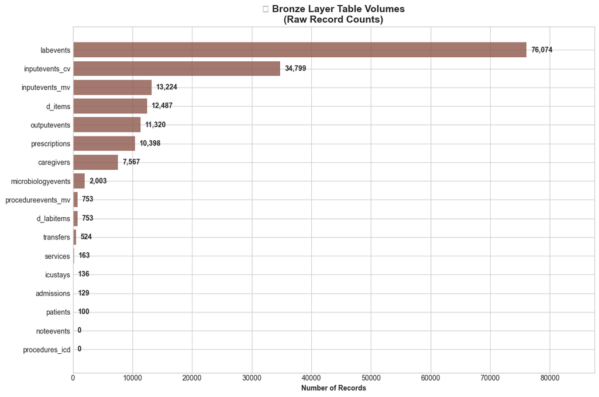

```
📝 Interpretation: This chart shows the raw volume of data ingested into the Bronze layer.
   Value labels clearly indicate the exact number of records in each table.
```

```python
# Visualize Record Counts with Value Labels
if not summary_df.empty:
    fig, ax = plt.subplots(figsize=(12, 8))

    bars = ax.barh(summary_df['Table'], summary_df['Records'],
                   color=COLORS['primary'], alpha=0.8)

    ax.set_xlabel('Number of Records', fontweight='bold')
    ax.set_title('📉 Bronze Layer Table Volumes\n(Raw Record Counts)',
                 fontsize=14, fontweight='bold')

    # Add value labels
    max_val = summary_df['Records'].max()
    for bar in bars:
        width = bar.get_width()
        label_x = width + (max_val * 0.01)  # spacing
        ax.text(label_x, bar.get_y() + bar.get_height()/2,
                f'{int(width):,}',
                ha='left', va='center', fontweight='bold', fontsize=10)

    # Extend x-axis slightly for labels
    ax.set_xlim(0, max_val * 1.15)

    plt.tight_layout()
    plt.show()
    print("\n📝 Interpretation: This chart shows the raw volume of data ingested into the Bronze layer.")
    print("   Value labels clearly indicate the exact number of records in each table.")
```

## 2. Sample Data Inspection

Reviewing the structure and content of key tables to ensure correct parsing.

```python
# Function to display sample data
def show_sample(table_name, limit=5):
    try:
        df = query_df(f"SELECT * FROM bronze.{table_name} LIMIT {limit}")
        print(f"\n📄 SAMPLE: {table_name.upper()} ({len(df)} rows shown)")
        print("-"*60)
        display(df)
        print(f"   Columns: {', '.join(df.columns.tolist())}")
    except Exception as e:
        print(f"Could not query {table_name}: {e}")
```

```python
from IPython.display import display

# Inspect core patient tables
show_sample('patients')
show_sample('admissions')
```

```
2026-01-01 14:55:09,715 INFO sqlalchemy.engine.Engine BEGIN (implicit)
2026-01-01 14:55:09,717 INFO sqlalchemy.engine.Engine SELECT * FROM bronze.patients LIMIT 5
2026-01-01 14:55:09,719 INFO sqlalchemy.engine.Engine [generated in 0.00204s] {}
2026-01-01 14:55:09,725 INFO sqlalchemy.engine.Engine COMMIT

📄 SAMPLE: PATIENTS (5 rows shown)
------------------------------------------------------------
```

|  | row_id | subject_id | gender | dob | dod | dod_hosp | dod_ssn | expire_flag | created_at | updated_at |
| --- | --- | --- | --- | --- | --- | --- | --- | --- | --- | --- |
| 0 | 9467 | 10006 | F | 2094-03-05 | 2165-08-12 | 2165-08-12 | 2165-08-12 | True | 2025-12-25 12:14:53.276330+00:00 | 2025-12-25 12:14:53.276330+00:00 |
| 1 | 9472 | 10011 | F | 2090-06-05 | 2126-08-28 | 2126-08-28 | NaT | True | 2025-12-25 12:14:53.276330+00:00 | 2025-12-25 12:14:53.276330+00:00 |
| 2 | 9474 | 10013 | F | 2038-09-03 | 2125-10-07 | 2125-10-07 | 2125-10-07 | True | 2025-12-25 12:14:53.276330+00:00 | 2025-12-25 12:14:53.276330+00:00 |
| 3 | 9478 | 10017 | F | 2075-09-21 | 2152-09-12 | NaT | 2152-09-12 | True | 2025-12-25 12:14:53.276330+00:00 | 2025-12-25 12:14:53.276330+00:00 |
| 4 | 9479 | 10019 | M | 2114-06-20 | 2163-05-15 | 2163-05-15 | 2163-05-15 | True | 2025-12-25 12:14:53.276330+00:00 | 2025-12-25 12:14:53.276330+00:00 |

```
   Columns: row_id, subject_id, gender, dob, dod, dod_hosp, dod_ssn, expire_flag, created_at, updated_at
2026-01-01 14:55:09,743 INFO sqlalchemy.engine.Engine BEGIN (implicit)
2026-01-01 14:55:09,744 INFO sqlalchemy.engine.Engine SELECT * FROM bronze.admissions LIMIT 5
2026-01-01 14:55:09,745 INFO sqlalchemy.engine.Engine [generated in 0.00073s] {}
2026-01-01 14:55:09,751 INFO sqlalchemy.engine.Engine COMMIT

📄 SAMPLE: ADMISSIONS (5 rows shown)
------------------------------------------------------------
```

|  | row_id | subject_id | hadm_id | admittime | dischtime | deathtime | admission_type | admission_location | discharge_location | insurance | language | religion | marital_status | ethnicity | edregtime | edouttime | diagnosis | hospital_expire_flag | has_chartevents_data | created_at | updated_at |
| --- | --- | --- | --- | --- | --- | --- | --- | --- | --- | --- | --- | --- | --- | --- | --- | --- | --- | --- | --- | --- | --- |
| 0 | 12258 | 10006 | 142345 | 2164-10-23 21:09:00 | 2164-11-01 17:15:00 | NaT | EMERGENCY | EMERGENCY ROOM ADMIT | HOME HEALTH CARE | Medicare | None | CATHOLIC | SEPARATED | BLACK/AFRICAN AMERICAN | 2164-10-23 16:43:00 | 2164-10-23 23:00:00 | SEPSIS | False | True | 2025-12-25 12:14:53.356919+00:00 | 2025-12-25 12:14:53.356919+00:00 |
| 1 | 12263 | 10011 | 105331 | 2126-08-14 22:32:00 | 2126-08-28 18:59:00 | 2126-08-28 18:59:00 | EMERGENCY | TRANSFER FROM HOSP/EXTRAM | DEAD/EXPIRED | Private | None | CATHOLIC | SINGLE | UNKNOWN/NOT SPECIFIED | NaT | NaT | HEPATITIS B | True | True | 2025-12-25 12:14:53.356919+00:00 | 2025-12-25 12:14:53.356919+00:00 |
| 2 | 12265 | 10013 | 165520 | 2125-10-04 23:36:00 | 2125-10-07 15:13:00 | 2125-10-07 15:13:00 | EMERGENCY | TRANSFER FROM HOSP/EXTRAM | DEAD/EXPIRED | Medicare | None | CATHOLIC | None | UNKNOWN/NOT SPECIFIED | NaT | NaT | SEPSIS | True | True | 2025-12-25 12:14:53.356919+00:00 | 2025-12-25 12:14:53.356919+00:00 |
| 3 | 12269 | 10017 | 199207 | 2149-05-26 17:19:00 | 2149-06-03 18:42:00 | NaT | EMERGENCY | EMERGENCY ROOM ADMIT | SNF | Medicare | None | CATHOLIC | DIVORCED | WHITE | 2149-05-26 12:08:00 | 2149-05-26 19:45:00 | HUMERAL FRACTURE | False | True | 2025-12-25 12:14:53.356919+00:00 | 2025-12-25 12:14:53.356919+00:00 |
| 4 | 12270 | 10019 | 177759 | 2163-05-14 20:43:00 | 2163-05-15 12:00:00 | 2163-05-15 12:00:00 | EMERGENCY | TRANSFER FROM HOSP/EXTRAM | DEAD/EXPIRED | Medicare | None | CATHOLIC | DIVORCED | WHITE | NaT | NaT | ALCOHOLIC HEPATITIS | True | True | 2025-12-25 12:14:53.356919+00:00 | 2025-12-25 12:14:53.356919+00:00 |

```
   Columns: row_id, subject_id, hadm_id, admittime, dischtime, deathtime, admission_type, admission_location, discharge_location, insurance, language, religion, marital_status, ethnicity, edregtime, edouttime, diagnosis, hospital_expire_flag, has_chartevents_data, created_at, updated_at
```

```python
# Inspect clinical event tables
show_sample('icustays')
show_sample('labevents')
show_sample('prescriptions')
```

```
2026-01-01 14:55:14,097 INFO sqlalchemy.engine.Engine BEGIN (implicit)
2026-01-01 14:55:14,098 INFO sqlalchemy.engine.Engine SELECT * FROM bronze.icustays LIMIT 5
2026-01-01 14:55:14,099 INFO sqlalchemy.engine.Engine [generated in 0.00086s] {}
2026-01-01 14:55:14,105 INFO sqlalchemy.engine.Engine COMMIT

📄 SAMPLE: ICUSTAYS (5 rows shown)
------------------------------------------------------------
```

|  | row_id | subject_id | hadm_id | icustay_id | dbsource | first_careunit | last_careunit | first_wardid | last_wardid | intime | outtime | los | created_at | updated_at |
| --- | --- | --- | --- | --- | --- | --- | --- | --- | --- | --- | --- | --- | --- | --- |
| 0 | 12742 | 10006 | 142345 | 206504 | carevue | MICU | MICU | 52 | 52 | 2164-10-23 21:10:15 | 2164-10-25 12:21:07 | 1.63 | 2025-12-25 12:14:53.425861+00:00 | 2025-12-25 12:14:53.425861+00:00 |
| 1 | 12747 | 10011 | 105331 | 232110 | carevue | MICU | MICU | 15 | 15 | 2126-08-14 22:34:00 | 2126-08-28 18:59:00 | 13.85 | 2025-12-25 12:14:53.425861+00:00 | 2025-12-25 12:14:53.425861+00:00 |
| 2 | 12749 | 10013 | 165520 | 264446 | carevue | MICU | MICU | 15 | 15 | 2125-10-04 23:38:00 | 2125-10-07 15:13:52 | 2.65 | 2025-12-25 12:14:53.425861+00:00 | 2025-12-25 12:14:53.425861+00:00 |
| 3 | 12754 | 10017 | 199207 | 204881 | carevue | CCU | CCU | 7 | 7 | 2149-05-29 18:52:29 | 2149-05-31 22:19:17 | 2.14 | 2025-12-25 12:14:53.425861+00:00 | 2025-12-25 12:14:53.425861+00:00 |
| 4 | 12755 | 10019 | 177759 | 228977 | carevue | MICU | MICU | 15 | 15 | 2163-05-14 20:43:56 | 2163-05-16 03:47:04 | 1.29 | 2025-12-25 12:14:53.425861+00:00 | 2025-12-25 12:14:53.425861+00:00 |

```
   Columns: row_id, subject_id, hadm_id, icustay_id, dbsource, first_careunit, last_careunit, first_wardid, last_wardid, intime, outtime, los, created_at, updated_at
2026-01-01 14:55:14,119 INFO sqlalchemy.engine.Engine BEGIN (implicit)
2026-01-01 14:55:14,120 INFO sqlalchemy.engine.Engine SELECT * FROM bronze.labevents LIMIT 5
2026-01-01 14:55:14,120 INFO sqlalchemy.engine.Engine [generated in 0.00062s] {}
2026-01-01 14:55:14,125 INFO sqlalchemy.engine.Engine COMMIT

📄 SAMPLE: LABEVENTS (5 rows shown)
------------------------------------------------------------
```

|  | row_id | subject_id | hadm_id | itemid | charttime | value | valuenum | valueuom | flag | created_at | updated_at |
| --- | --- | --- | --- | --- | --- | --- | --- | --- | --- | --- | --- |
| 0 | 6244563 | 10006 | None | 50868 | 2164-09-24 20:21:00 | 19 | 19.00 | mEq/L | None | 2025-12-25 12:14:56.327747+00:00 | 2025-12-25 12:14:56.327747+00:00 |
| 1 | 6244564 | 10006 | None | 50882 | 2164-09-24 20:21:00 | 27 | 27.00 | mEq/L | None | 2025-12-25 12:14:56.327747+00:00 | 2025-12-25 12:14:56.327747+00:00 |
| 2 | 6244565 | 10006 | None | 50893 | 2164-09-24 20:21:00 | 10.0 | 10.00 | mg/dL | None | 2025-12-25 12:14:56.327747+00:00 | 2025-12-25 12:14:56.327747+00:00 |
| 3 | 6244566 | 10006 | None | 50902 | 2164-09-24 20:21:00 | 97 | 97.00 | mEq/L | None | 2025-12-25 12:14:56.327747+00:00 | 2025-12-25 12:14:56.327747+00:00 |
| 4 | 6244567 | 10006 | None | 50912 | 2164-09-24 20:21:00 | 7.0 | 7.00 | mg/dL | abnormal | 2025-12-25 12:14:56.327747+00:00 | 2025-12-25 12:14:56.327747+00:00 |

```
   Columns: row_id, subject_id, hadm_id, itemid, charttime, value, valuenum, valueuom, flag, created_at, updated_at
2026-01-01 14:55:14,137 INFO sqlalchemy.engine.Engine BEGIN (implicit)
2026-01-01 14:55:14,138 INFO sqlalchemy.engine.Engine SELECT * FROM bronze.prescriptions LIMIT 5
2026-01-01 14:55:14,139 INFO sqlalchemy.engine.Engine [generated in 0.00066s] {}
2026-01-01 14:55:14,153 INFO sqlalchemy.engine.Engine COMMIT

📄 SAMPLE: PRESCRIPTIONS (5 rows shown)
------------------------------------------------------------
```

|  | row_id | subject_id | hadm_id | icustay_id | startdate | enddate | drug_type | drug | drug_name_poe | drug_name_generic | formulary_drug_cd | gsn | ndc | prod_strength | dose_val_rx | dose_unit_rx | form_val_disp | form_unit_disp | route | created_at | updated_at |
| --- | --- | --- | --- | --- | --- | --- | --- | --- | --- | --- | --- | --- | --- | --- | --- | --- | --- | --- | --- | --- | --- |
| 0 | 32600 | 42458 | 159647 | None | 2146-07-21 | 2146-07-22 | MAIN | Pneumococcal Vac Polyvalent | Pneumococcal Vac Polyvalent | PNEUMOcoccal Vac Polyvalent | PNEU25I | 048548 | 00006494300 | 25mcg/0.5mL Vial | 0.5 | mL | 1 | VIAL | IM | 2025-12-25 12:15:19.207283+00:00 | 2025-12-25 12:15:19.207283+00:00 |
| 1 | 32601 | 42458 | 159647 | None | 2146-07-21 | 2146-07-22 | MAIN | Bisacodyl | Bisacodyl | Bisacodyl | BISA5 | 002947 | 00536338101 | 5 mg Tab | 10 | mg | 2 | TAB | PO | 2025-12-25 12:15:19.207283+00:00 | 2025-12-25 12:15:19.207283+00:00 |
| 2 | 32602 | 42458 | 159647 | None | 2146-07-21 | 2146-07-22 | MAIN | Bisacodyl | Bisacodyl | Bisacodyl (Rectal) | BISA10R | 002944 | 00574705050 | 10mg Suppository | 10 | mg | 1 | SUPP | PR | 2025-12-25 12:15:19.207283+00:00 | 2025-12-25 12:15:19.207283+00:00 |
| 3 | 32603 | 42458 | 159647 | None | 2146-07-21 | 2146-07-22 | MAIN | Senna | Senna | Senna | SENN187 | 019964 | 00904516561 | 1 Tablet | 1 | TAB | 1 | TAB | PO | 2025-12-25 12:15:19.207283+00:00 | 2025-12-25 12:15:19.207283+00:00 |
| 4 | 32604 | 42458 | 159647 | None | 2146-07-21 | 2146-07-21 | MAIN | Docusate Sodium (Liquid) | Docusate Sodium (Liquid) | Docusate Sodium (Liquid) | DOCU100L | 003017 | 00121054410 | 100mg UD Cup | 100 | mg | 1 | UDCUP | PO | 2025-12-25 12:15:19.207283+00:00 | 2025-12-25 12:15:19.207283+00:00 |

```
   Columns: row_id, subject_id, hadm_id, icustay_id, startdate, enddate, drug_type, drug, drug_name_poe, drug_name_generic, formulary_drug_cd, gsn, ndc, prod_strength, dose_val_rx, dose_unit_rx, form_val_disp, form_unit_disp, route, created_at, updated_at
```

```python
# Inspect definitions/dictionaries
show_sample('d_labitems')
show_sample('d_items')
```

```
2026-01-01 14:56:50,266 INFO sqlalchemy.engine.Engine BEGIN (implicit)
2026-01-01 14:56:50,268 INFO sqlalchemy.engine.Engine SELECT * FROM bronze.d_labitems LIMIT 5
2026-01-01 14:56:50,270 INFO sqlalchemy.engine.Engine [generated in 0.00149s] {}
2026-01-01 14:56:50,274 INFO sqlalchemy.engine.Engine COMMIT

📄 SAMPLE: D_LABITEMS (5 rows shown)
------------------------------------------------------------
```

|  | row_id | itemid | label | fluid | category | loinc_code | created_at | updated_at |
| --- | --- | --- | --- | --- | --- | --- | --- | --- |
| 0 | 1 | 50800 | SPECIMEN TYPE | BLOOD | BLOOD GAS | None | 2025-12-25 12:14:56.190569+00:00 | 2025-12-25 12:14:56.190569+00:00 |
| 1 | 2 | 50801 | Alveolar-arterial Gradient | Blood | Blood Gas | 19991-9 | 2025-12-25 12:14:56.190569+00:00 | 2025-12-25 12:14:56.190569+00:00 |
| 2 | 3 | 50802 | Base Excess | Blood | Blood Gas | 11555-0 | 2025-12-25 12:14:56.190569+00:00 | 2025-12-25 12:14:56.190569+00:00 |
| 3 | 4 | 50803 | Calculated Bicarbonate, Whole Blood | Blood | Blood Gas | 1959-6 | 2025-12-25 12:14:56.190569+00:00 | 2025-12-25 12:14:56.190569+00:00 |
| 4 | 5 | 50804 | Calculated Total CO2 | Blood | Blood Gas | 34728-6 | 2025-12-25 12:14:56.190569+00:00 | 2025-12-25 12:14:56.190569+00:00 |

```
   Columns: row_id, itemid, label, fluid, category, loinc_code, created_at, updated_at
2026-01-01 14:56:50,286 INFO sqlalchemy.engine.Engine BEGIN (implicit)
2026-01-01 14:56:50,287 INFO sqlalchemy.engine.Engine SELECT * FROM bronze.d_items LIMIT 5
2026-01-01 14:56:50,289 INFO sqlalchemy.engine.Engine [cached since 89.9s ago] {}
2026-01-01 14:56:50,293 INFO sqlalchemy.engine.Engine COMMIT

📄 SAMPLE: D_ITEMS (5 rows shown)
------------------------------------------------------------
```

|  | row_id | itemid | label | abbreviation | dbsource | linksto | category | unitname | param_type | conceptid | created_at | updated_at |
| --- | --- | --- | --- | --- | --- | --- | --- | --- | --- | --- | --- | --- |
| 0 | 1 | 1435 | Sustained Nystamus | None | carevue | chartevents | None | None | None | None | 2025-12-25 12:14:54.687374+00:00 | 2025-12-25 12:14:54.687374+00:00 |
| 1 | 2 | 1436 | Tactile Disturbances | None | carevue | chartevents | None | None | None | None | 2025-12-25 12:14:54.687374+00:00 | 2025-12-25 12:14:54.687374+00:00 |
| 2 | 3 | 1437 | Tremor | None | carevue | chartevents | None | None | None | None | 2025-12-25 12:14:54.687374+00:00 | 2025-12-25 12:14:54.687374+00:00 |
| 3 | 4 | 1438 | Ulnar Pulse [Right] | None | carevue | chartevents | None | None | None | None | 2025-12-25 12:14:54.687374+00:00 | 2025-12-25 12:14:54.687374+00:00 |
| 4 | 5 | 1439 | Visual Disturbances | None | carevue | chartevents | None | None | None | None | 2025-12-25 12:14:54.687374+00:00 | 2025-12-25 12:14:54.687374+00:00 |

```
   Columns: row_id, itemid, label, abbreviation, dbsource, linksto, category, unitname, param_type, conceptid, created_at, updated_at
```

## 3. Data Quality Overview

Checking for null values in critical identifying columns (Subject ID, Admission ID).

```python
integrity_checks = [
    ('patients', 'subject_id'),
    ('admissions', 'hadm_id'),
    ('icustays', 'icustay_id'),
    ('labevents', 'itemid'),
    ('prescriptions', 'drug')
]

print("🛡️ NULL VALUE CHECK (Critical ID Columns)")
print("="*50)
print(f"{'Table':<20} | {'Column':<15} | {'Null Count':<10}")
print("-"*50)

for table, col in integrity_checks:
    try:
        null_cnt = query_df(f"""
            SELECT COUNT(*) as c
            FROM bronze.{table}
            WHERE {col} IS NULL
        """).iloc[0]['c']

        status = "✅" if null_cnt == 0 else "⚠️"
        print(f"{table:<20} | {col:<15} | {null_cnt:<10} {status}")
    except:
        print(f"{table:<20} | {col:<15} | {'N/A':<10} ❌")
```

[output not shown]

## 4. Conclusion

```python
print("✅ BRONZE LAYER ANALYSIS COMPLETE")
```

[output not shown]